# Association Rules for Adventure Work Dataset

Author

Oscar Hernandez Mata

```r
library(arules)
library(readr)
```

In this project I wanted to discover relationships in dataset AdventureWorkDW considering whether a costumer could likely be classified as a potential bike buyer or not according to a set of characteristics like ownership of a home, ownership of a car, commute distance, and children at home. Hence, I created a subset of the dataset AdventureWorkDW using the subset function, with the columns: age, number of children at home, income, house owner, educational level, number of cars owned. Then, I converted the data type with as.factor function that arule friendly, that is, factor.

Next, I installed the arules package in Rstudio to build association rules that analyze the data and uncover the relationship between products and costumers. Then, I executed the apriori algorithm and set a minimum support of 0.04, a confidence threshold of 0.7, and as the right-hand side of the rules “BikeBuyer=Buyer” and “BikeBuyer=Non-buyer” to explore the association rules related to these two attributes. Finally, I sorted by count and inspected 1:5 using the sorted and inspect functions.

```r
rm(list=ls())
AdventureWorksDataMiningInput <- read_csv("AdventureWorksDataMiningInput.csv")
AdventureWorksDW=AdventureWorksDataMiningInput
```

```r
table(AdventureWorksDW$MaritalStatus)
```

```
    M     S
10011  8473
```

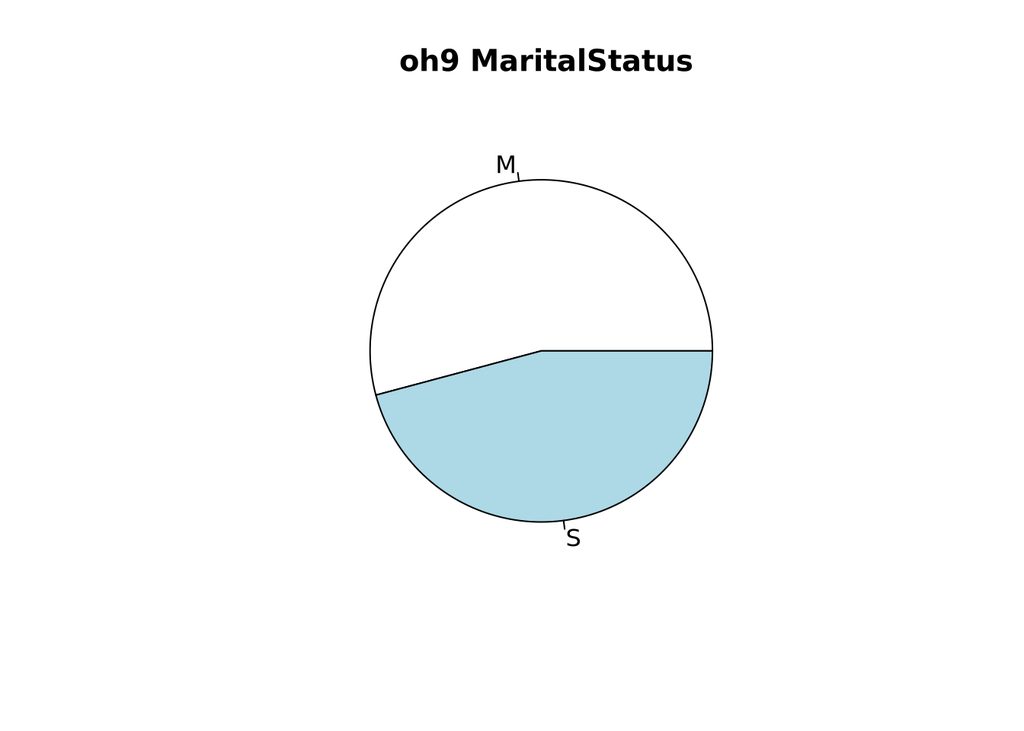

```r
pie(table(AdventureWorksDW$MaritalStatus),main=" oh9 MaritalStatus")
```

```r
table(AdventureWorksDW$Gender)
```

```
   F    M
9133 9351
```

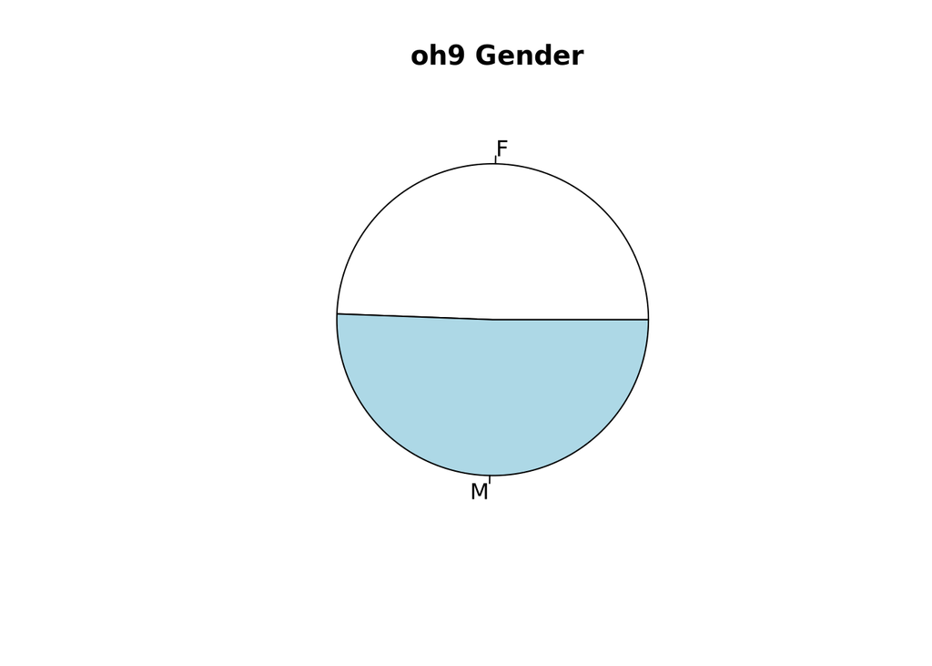

```r
pie(table(AdventureWorksDW$Gender),main=" oh9 Gender")
```

```r
table(AdventureWorksDW$YearlyIncome)
```

```
    High      Low Moderate
    6731     5209     6544
```

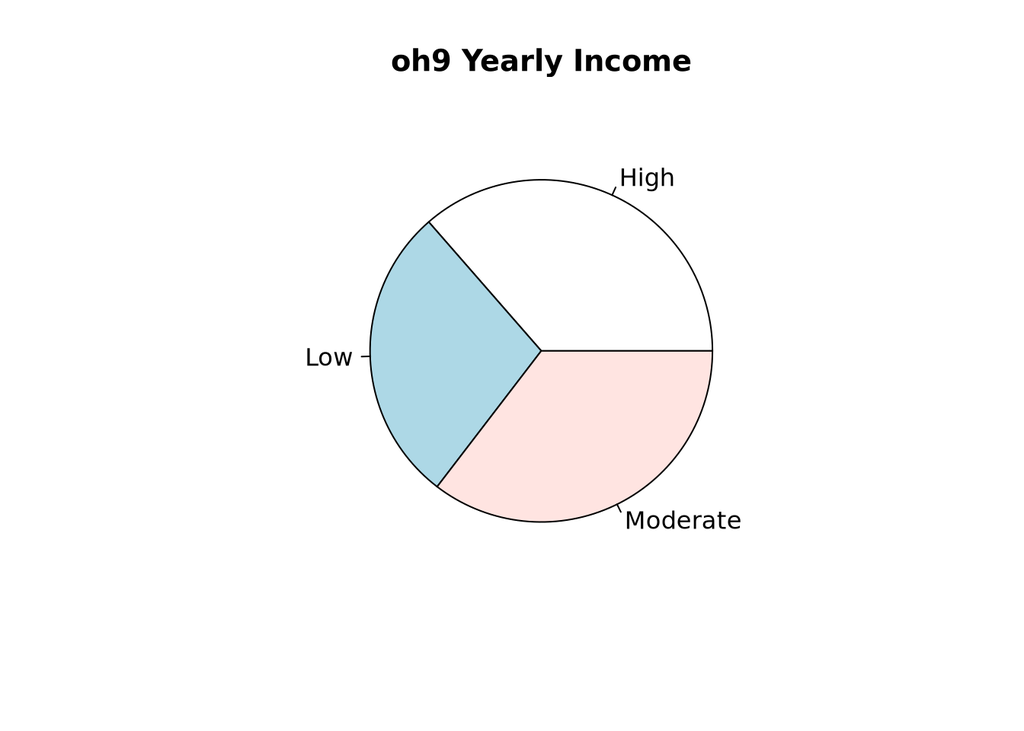

```r
pie(table(AdventureWorksDW$YearlyIncome), main="oh9 Yearly Income")
```

```r
table(AdventureWorksDW$TotalChildren)
```

```
   0    1    2    3    4    5
5165 3619 3779 2194 2303 1424
```

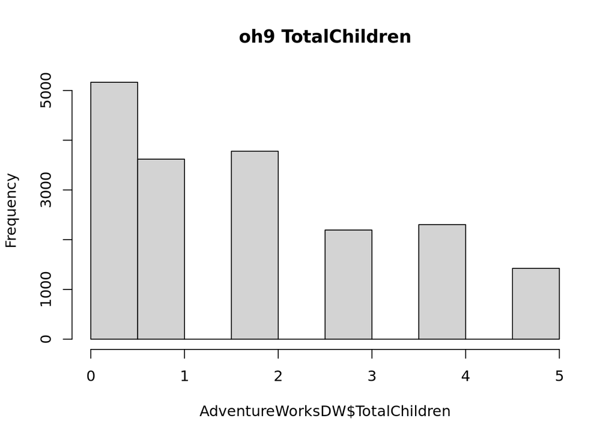

```r
hist(AdventureWorksDW$TotalChildren, main="oh9 TotalChildren")
```

```r
table(AdventureWorksDW$NumberChildrenAtHome)
```

```
    0     1     2     3     4     5
11116  2460  1648  1204  1089   967
```

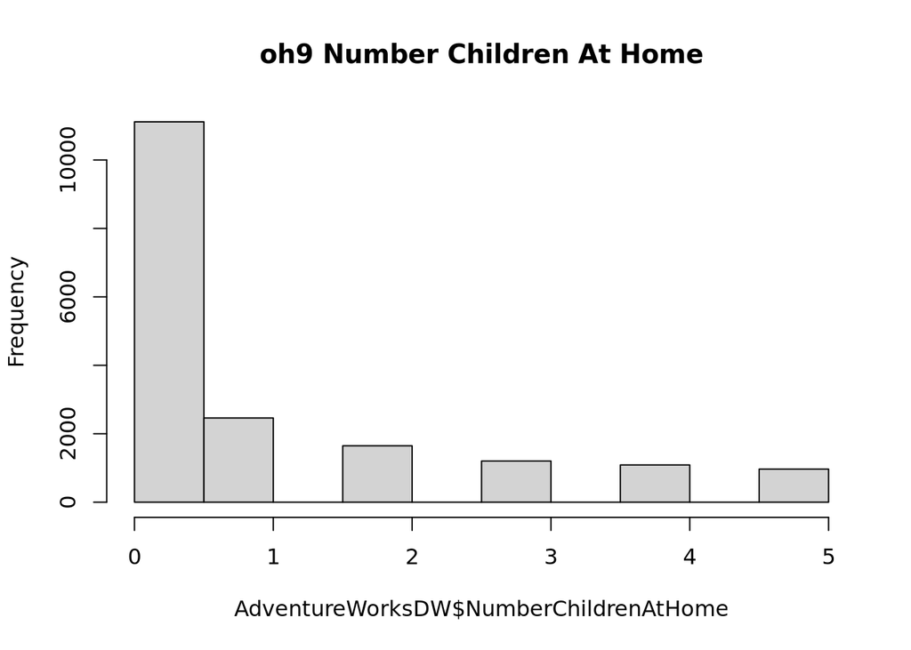

```r
hist(AdventureWorksDW$NumberChildrenAtHome, main="oh9 Number Children At Home")
```

```r
table(AdventureWorksDW$EducationLevel)
```

```
          Bachelors     Graduate Degree         High School     Partial College
               5356                3189                3294                5064
Partial High School
               1581
```

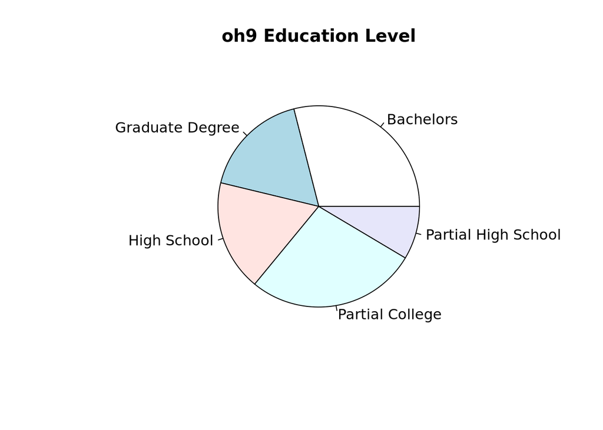

```r
pie(table(AdventureWorksDW$EducationLevel), main="oh9 Education Level")
```

```r
table(AdventureWorksDW$Occupation)
```

```
      Clerical     Management         Manual   Professional Skilled Manual
          2928           3075           2384           5520           4577
```

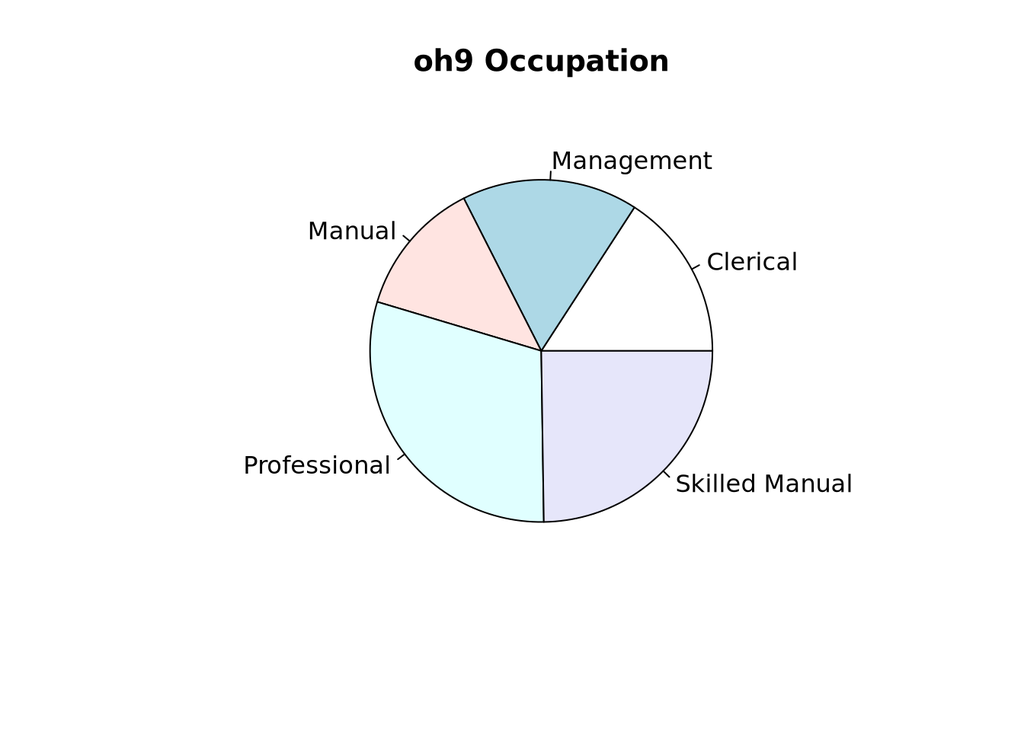

```r
pie(table(AdventureWorksDW$Occupation), main="oh9 Occupation")
```

```r
table(AdventureWorksDW$HouseOwnerFlag)
```

```
    0     1
 5982 12502
```

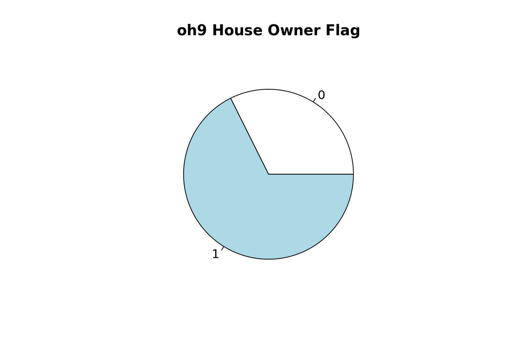

```r
pie(table(AdventureWorksDW$HouseOwnerFlag), main="oh9 House Owner Flag")
```

```r
table(AdventureWorksDW$NumberCarsOwned)
```

```
   0    1    2    3    4
4238 4883 6457 1645 1261
```

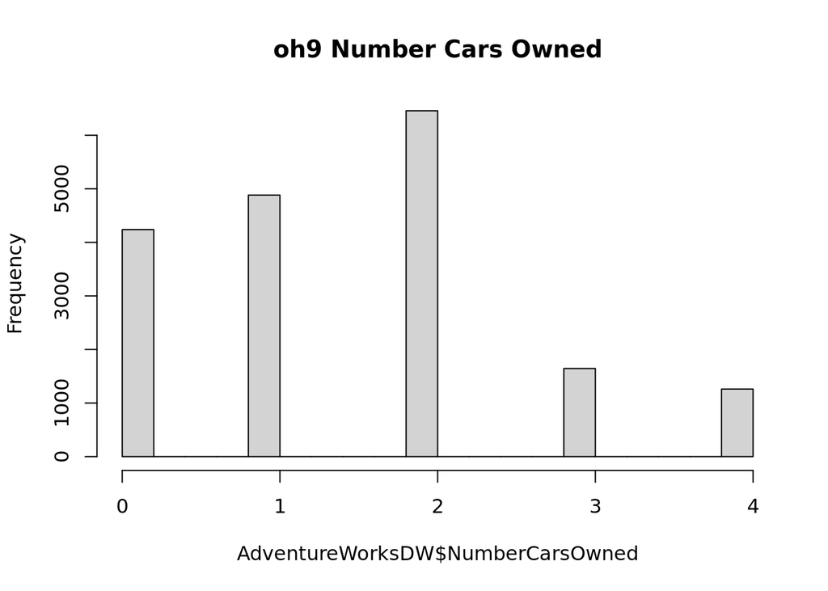

```r
hist(AdventureWorksDW$NumberCarsOwned, main="oh9 Number Cars Owned")
```

```r
table(AdventureWorksDW$FirstPurchaseYearMonth)
```

```
201712 201801 201802 201803 201804 201805 201806 201807 201808 201809 201810
    14    144    144    150    157    174    230    188    193    185    221
201811 201812 201901 201902 201903 201904 201905 201906 201907 201908 201909
   208    222    252    260    212    219    207    318    246    294    269
201910 201911 201912 202001 202002 202003 202004 202005 202006 202007 202008
   313    324    311    325   1087   1164   1088   1141   1154   1052   1074
202009 202010 202011 202012 202101
  1029   1134   1133   1142    506
```

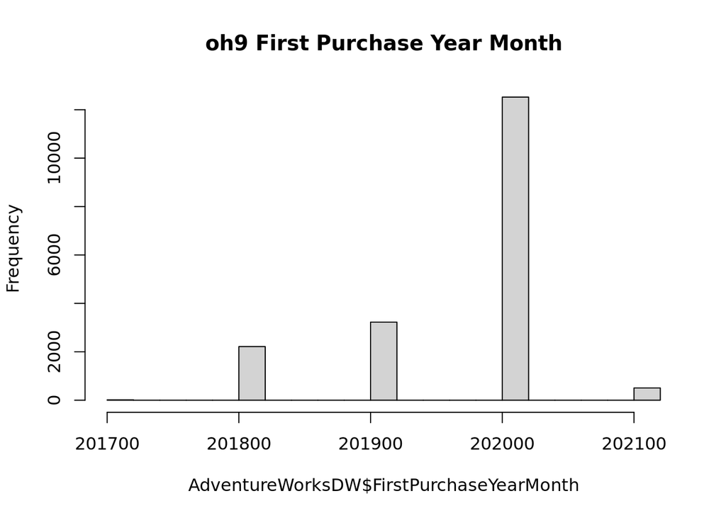

```r
hist(AdventureWorksDW$FirstPurchaseYearMonth, main="oh9 First Purchase Year Month")
```

```r
table(AdventureWorksDW$CommuteDistance)
```

```
      0 to 1       1 to 2       2 to 5      5 to 10 More than 10
        6310         3232         3234         3214         2494
```

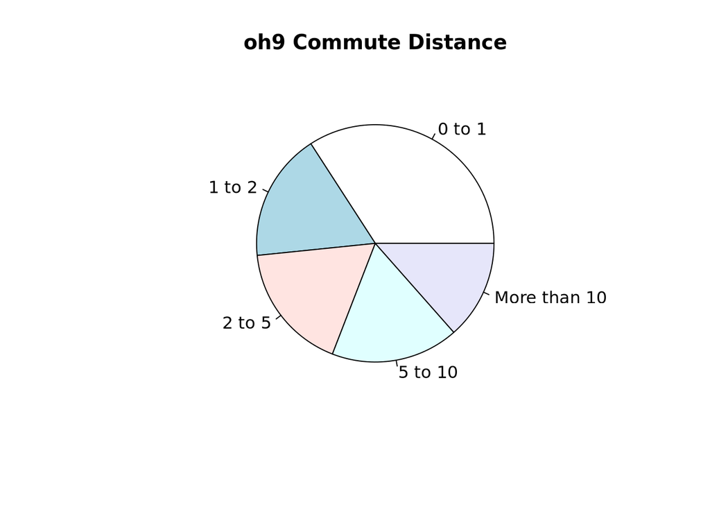

```r
pie(table(AdventureWorksDW$CommuteDistance), main="oh9 Commute Distance")
```

```r
table(AdventureWorksDW$Region)
```

```
       Europe North America       Pacific
         5503          9390          3591
```

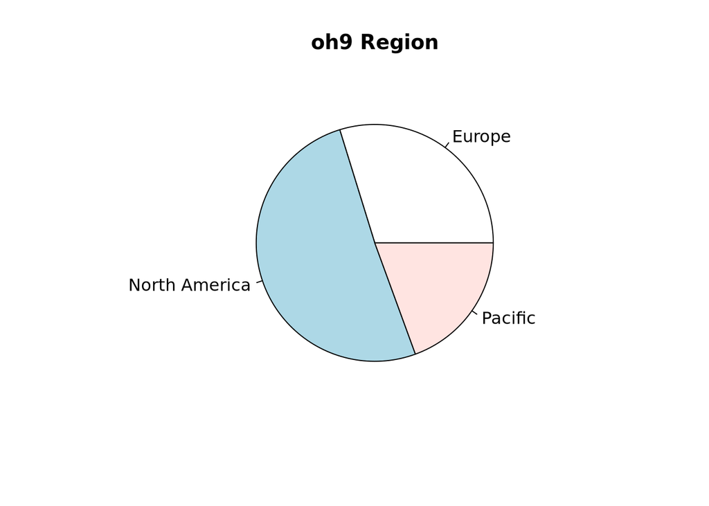

```r
pie(table(AdventureWorksDW$Region), main="oh9 Region")
```

```r
table(AdventureWorksDW$AgeRange)
```

```
   30s    40s    50s    60s 70plus
  2156   6535   4934   3063   1796
```

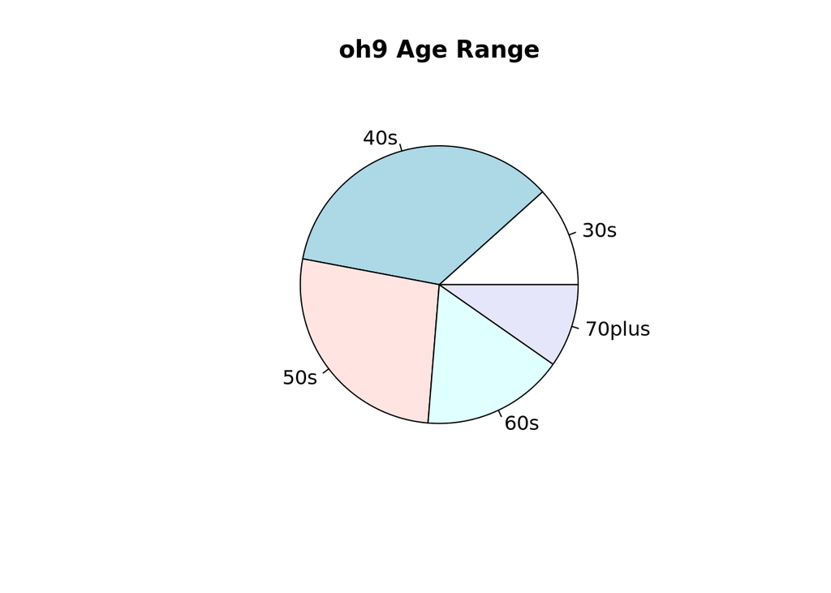

```r
pie(table(AdventureWorksDW$AgeRange), main="oh9 Age Range")
```

```r
table(AdventureWorksDW$BikeBuyer)
```

```
    Buyer Non-buyer
     9132      9352
```

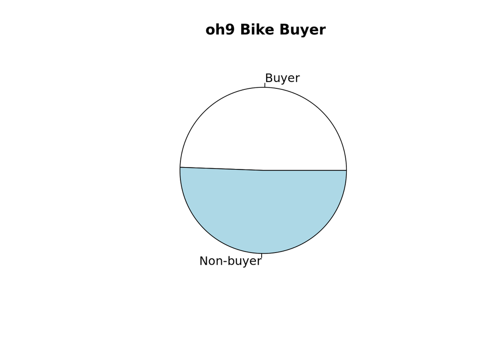

```r
pie(table(AdventureWorksDW$BikeBuyer),main=" oh9 Bike Buyer")
```

```r
oh9_arules_input=subset(AdventureWorksDW,
             select = c("MaritalStatus",  "Gender", "YearlyIncome", "TotalChildren",
                        "NumberChildrenAtHome", "EducationLevel", "Occupation", "HouseOwnerFlag",
                        "NumberCarsOwned", "FirstPurchaseYearMonth",  "CommuteDistance",
                        "Region", "AgeRange","BikeBuyer"))
str(oh9_arules_input)
```

```
tibble [18,484 × 14] (S3: tbl_df/tbl/data.frame)
 $ MaritalStatus         : chr [1:18484] "M" "S" "M" "S" ...
 $ Gender                : chr [1:18484] "M" "M" "M" "F" ...
 $ YearlyIncome          : chr [1:18484] "High" "Moderate" "Moderate" "High" ...
 $ TotalChildren         : num [1:18484] 2 3 3 0 5 0 0 3 4 0 ...
 $ NumberChildrenAtHome  : num [1:18484] 0 3 3 0 5 0 0 3 4 0 ...
 $ EducationLevel        : chr [1:18484] "Bachelors" "Bachelors" "Bachelors" "Bachelors" ...
 $ Occupation            : chr [1:18484] "Professional" "Professional" "Professional" "Professional" ...
 $ HouseOwnerFlag        : num [1:18484] 1 0 1 0 1 1 1 1 1 0 ...
 $ NumberCarsOwned       : num [1:18484] 0 1 1 1 4 1 1 2 3 1 ...
 $ FirstPurchaseYearMonth: num [1:18484] 201801 201801 201801 201712 201801 ...
 $ CommuteDistance       : chr [1:18484] "1 to 2" "0 to 1" "2 to 5" "5 to 10" ...
 $ Region                : chr [1:18484] "Pacific" "Pacific" "Pacific" "Pacific" ...
 $ AgeRange              : chr [1:18484] "50s" "40s" "50s" "40s" ...
 $ BikeBuyer             : chr [1:18484] "Buyer" "Buyer" "Buyer" "Buyer" ...
```

```r
#Convert to data types that are arules friendly
oh9_arules_input$TotalChildren<-as.factor(oh9_arules_input$TotalChildren)
oh9_arules_input$NumberChildrenAtHome<-as.factor(oh9_arules_input$NumberChildrenAtHome)
oh9_arules_input$HouseOwnerFlag<-as.factor(oh9_arules_input$HouseOwnerFlag)
oh9_arules_input$NumberCarsOwned<-as.factor(oh9_arules_input$NumberCarsOwned)
oh9_arules_input$FirstPurchaseYearMonth<-as.factor(oh9_arules_input$FirstPurchaseYearMonth)
oh9_arules_input$BikeBuyer<-as.factor(oh9_arules_input$BikeBuyer)
```

```r
str(oh9_arules_input)
```

```
tibble [18,484 × 14] (S3: tbl_df/tbl/data.frame)
 $ MaritalStatus         : chr [1:18484] "M" "S" "M" "S" ...
 $ Gender                : chr [1:18484] "M" "M" "M" "F" ...
 $ YearlyIncome          : chr [1:18484] "High" "Moderate" "Moderate" "High" ...
 $ TotalChildren         : Factor w/ 6 levels "0","1","2","3",..: 3 4 4 1 6 1 1 4 5 1 ...
 $ NumberChildrenAtHome  : Factor w/ 6 levels "0","1","2","3",..: 1 4 4 1 6 1 1 4 5 1 ...
 $ EducationLevel        : chr [1:18484] "Bachelors" "Bachelors" "Bachelors" "Bachelors" ...
 $ Occupation            : chr [1:18484] "Professional" "Professional" "Professional" "Professional" ...
 $ HouseOwnerFlag        : Factor w/ 2 levels "0","1": 2 1 2 1 2 2 2 2 2 1 ...
 $ NumberCarsOwned       : Factor w/ 5 levels "0","1","2","3",..: 1 2 2 2 5 2 2 3 4 2 ...
 $ FirstPurchaseYearMonth: Factor w/ 38 levels "201712","201801",..: 2 2 2 1 2 1 2 2 2 2 ...
 $ CommuteDistance       : chr [1:18484] "1 to 2" "0 to 1" "2 to 5" "5 to 10" ...
 $ Region                : chr [1:18484] "Pacific" "Pacific" "Pacific" "Pacific" ...
 $ AgeRange              : chr [1:18484] "50s" "40s" "50s" "40s" ...
 $ BikeBuyer             : Factor w/ 2 levels "Buyer","Non-buyer": 1 1 1 1 1 1 1 1 1 1 ...
```

```r
#Execute the Apriori algorithm
#Minimum length is 3
#Minimum support is 0.04
#Minimum confidence is 0.7
oh9_rules<-apriori(oh9_arules_input,
               parameter=list(minlen=3, supp=0.04, conf=0.7),
               appearance=list(rhs=c("BikeBuyer=Non-buyer","BikeBuyer=Buyer"),
               default="lhs"), control=list(verbose=F))
```

```r
oh9_rules.sorted <-sort(oh9_rules, by="count")
inspect(oh9_rules.sorted[1:5])
```

```
    lhs                            rhs                      support confidence   coverage     lift count
[1] {NumberCarsOwned=0,
     AgeRange=40s}              => {BikeBuyer=Buyer}     0.08391041  0.7180556 0.11685782 1.453410  1551
[2] {YearlyIncome=Low,
     NumberCarsOwned=2}         => {BikeBuyer=Non-buyer} 0.07942004  0.7136607 0.11128544 1.410533  1468
[3] {HouseOwnerFlag=1,
     NumberCarsOwned=0,
     AgeRange=40s}              => {BikeBuyer=Buyer}     0.06703095  0.7149452 0.09375676 1.447114  1239
[4] {EducationLevel=Bachelors,
     NumberCarsOwned=0}         => {BikeBuyer=Buyer}     0.05767150  0.7311385 0.07887903 1.479891  1066
[5] {NumberChildrenAtHome=0,
     NumberCarsOwned=0,
     AgeRange=40s}              => {BikeBuyer=Buyer}     0.05653538  0.7177198 0.07877083 1.452730  1045
```

```r
oh9.sorted <-sort(oh9_rules, by="support")
inspect(oh9_rules.sorted[1:5])
```

```
    lhs                            rhs                      support confidence   coverage     lift count
[1] {NumberCarsOwned=0,
     AgeRange=40s}              => {BikeBuyer=Buyer}     0.08391041  0.7180556 0.11685782 1.453410  1551
[2] {YearlyIncome=Low,
     NumberCarsOwned=2}         => {BikeBuyer=Non-buyer} 0.07942004  0.7136607 0.11128544 1.410533  1468
[3] {HouseOwnerFlag=1,
     NumberCarsOwned=0,
     AgeRange=40s}              => {BikeBuyer=Buyer}     0.06703095  0.7149452 0.09375676 1.447114  1239
[4] {EducationLevel=Bachelors,
     NumberCarsOwned=0}         => {BikeBuyer=Buyer}     0.05767150  0.7311385 0.07887903 1.479891  1066
[5] {NumberChildrenAtHome=0,
     NumberCarsOwned=0,
     AgeRange=40s}              => {BikeBuyer=Buyer}     0.05653538  0.7177198 0.07877083 1.452730  1045
```

```r
oh9_rules.sorted <-sort(oh9_rules, by="confidence")
inspect(oh9_rules.sorted[1:5])
```

```
    lhs                          rhs                  support confidence   coverage     lift count
[1] {TotalChildren=0,
     NumberChildrenAtHome=0,
     NumberCarsOwned=0}       => {BikeBuyer=Buyer} 0.04106254  0.7776639 0.05280242 1.574063   759
[2] {NumberChildrenAtHome=0,
     Occupation=Clerical,
     NumberCarsOwned=0}       => {BikeBuyer=Buyer} 0.04165765  0.7723170 0.05393854 1.563240   770
[3] {TotalChildren=0,
     NumberCarsOwned=0}       => {BikeBuyer=Buyer} 0.04122484  0.7696970 0.05355984 1.557937   762
[4] {Occupation=Clerical,
     NumberCarsOwned=0}       => {BikeBuyer=Buyer} 0.04879896  0.7605396 0.06416360 1.539402   902
[5] {NumberChildrenAtHome=0,
     NumberCarsOwned=0,
     CommuteDistance=0 to 1,
     AgeRange=40s}            => {BikeBuyer=Buyer} 0.04014283  0.7517730 0.05339753 1.521657   742
```

**Interpretation of the top 5 confidence rules:**

**Rule 1**: Costumers with no children, with no children at home, and no cars, there is a confidence of 77.7% that they will be potential bike buyers. **Rule 2**: Costumers with no children at home, no cars, and a clerical occupation, there is confidence of 77.2% that they will be potential bike buyers. **Rule 3**: Costumers with no children and no cars, there is confidence of 76.9% that they will be potential bike buyers. **Rule 4**: Costumers with no cars and a clerical occupation, there is confidence of 76% that they will be potential bike buyers. **Rule 5**: Costumers in their 40s, with no children at home, with no cars, and a commute distance of 0 to 1 mile, there is confidence of 75.1% that they will be potential bike buyers.

```r
oh9_rules.sorted <-sort(oh9_rules, by="lift")
inspect(oh9_rules.sorted[1:5])
```

```
    lhs                          rhs                  support confidence   coverage     lift count
[1] {TotalChildren=0,
     NumberChildrenAtHome=0,
     NumberCarsOwned=0}       => {BikeBuyer=Buyer} 0.04106254  0.7776639 0.05280242 1.574063   759
[2] {NumberChildrenAtHome=0,
     Occupation=Clerical,
     NumberCarsOwned=0}       => {BikeBuyer=Buyer} 0.04165765  0.7723170 0.05393854 1.563240   770
[3] {TotalChildren=0,
     NumberCarsOwned=0}       => {BikeBuyer=Buyer} 0.04122484  0.7696970 0.05355984 1.557937   762
[4] {Occupation=Clerical,
     NumberCarsOwned=0}       => {BikeBuyer=Buyer} 0.04879896  0.7605396 0.06416360 1.539402   902
[5] {NumberChildrenAtHome=0,
     NumberCarsOwned=0,
     CommuteDistance=0 to 1,
     AgeRange=40s}            => {BikeBuyer=Buyer} 0.04014283  0.7517730 0.05339753 1.521657   742
```

**Interpretation of the top 5 lift rules:**

**Rule 1:** A positive association (1.57) exists between customers with no children, no cars, and no children at home with bike buying. **Rule 2:** There is a positive association (1.56) between customers with no children at home, with no cars, and a clerical occupation with bike buying. **Rule 3:** A positive association (1.55) exists between customers with no children and no cars with bike buying. **Rule 4:** A positive association (1.53) exists between customers with no cars and a clerical occupation with bike buying. **Rule 5:** There is a positive association (1.52) between customers in their 40s with no children at home, no cars, and a commute distance of 0 to 1 mile with bike buying.

```r
oh9_rules.sorted <-sort(oh9_rules, by="lift", decreasing = FALSE)
inspect(oh9_rules.sorted[1:5])
```

```
    lhs                              rhs                      support confidence   coverage     lift count
[1] {NumberCarsOwned=2,
     CommuteDistance=5 to 10,
     Region=North America}        => {BikeBuyer=Non-buyer} 0.04685133  0.7000808 0.06692274 1.383693   866
[2] {NumberChildrenAtHome=0,
     HouseOwnerFlag=1,
     CommuteDistance=5 to 10,
     Region=North America}        => {BikeBuyer=Non-buyer} 0.04647262  0.7006525 0.06632763 1.384823   859
[3] {NumberChildrenAtHome=0,
     EducationLevel=High School,
     Region=North America}        => {BikeBuyer=Non-buyer} 0.04127894  0.7019319 0.05880762 1.387351   763
[4] {MaritalStatus=S,
     YearlyIncome=Low,
     NumberCarsOwned=2}           => {BikeBuyer=Non-buyer} 0.04214456  0.7030686 0.05994374 1.389598   779
[5] {TotalChildren=0,
     CommuteDistance=5 to 10}     => {BikeBuyer=Non-buyer} 0.04068383  0.7034612 0.05783380 1.390374   752
```

**Interpretation of the top 5 lift rules using the reverse sort:**

**Rule 1:** A positive association (1.383) exists between customers with two cars, a commute distance of 5 to 10 miles, and living in North America with non-bike buying. **Rule 2:** There is a positive association (1.384) between customers who own a house, with no children at home, with a commute distance from 5 to 10 miles, and living in North America with non-bike buying. **Rule 3**: A positive association (1.387) exists between customers living in North America with a high school degree and no children at home with non-bike buying. **Rule 4:** A positive association (1.389) exists between customers who own two cars, with low income, and are single with non-bike buying. **Rule 5:** There is a positive association (1.390) between customers with no children and a commute distance between 5 to 10 miles with non-bike buying.